# Assignment 1: Air Transport Since 2013, Winners and Losers

Christina Moss and Hao Zhu

2025-02-07

# Part One: Analyzing Winning and Losing Airports (2013-2023)

This analysis examines changes in airport operations of major large and small hubs over the past decade (2013-2023). Using data from the FAA’s Terminal Area Forecast, we define winners as airports that experienced the largest percentage increases in commuter enplanements and, conversly, losing airports as those which experienced the greatest decline. Commuter enplanements is our key metric for measuring success because it signifies an increase (or decrease) in connecting traffic, which is an important indicator for defining an airport as a hub. More connections means more total operations, signifying an airport with a steady flow of traffic rather than the rush hour and lulls dynamic of origin and destination airports.

We focus our analysis on percentage change because we wanted to particularly highlight those airports experiencing the most growth (or greatest decline). Identifying which airports have experienced the most growth over the last decade can play a role in highlighting where airlines should prioritize investment and expansion.

## Defining Winners and Losers - Data Exploration

Here we identify large and small airport hubs with a commuter enplanement number of greater than 100,000 passengers.

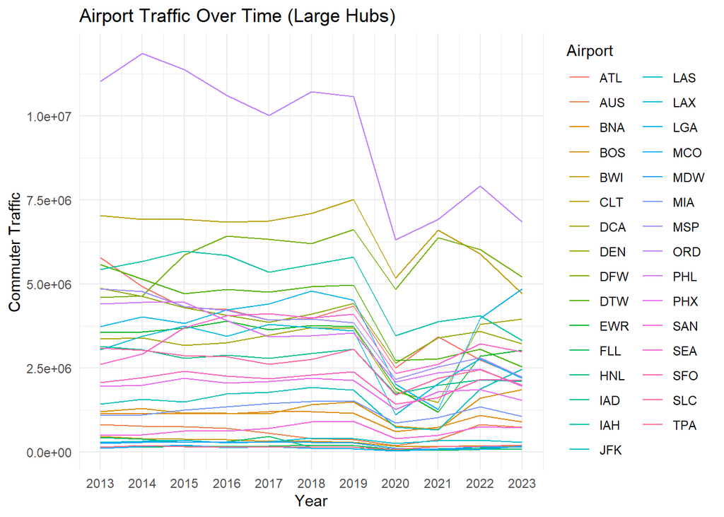

```r
hub_large <- dat_large %>%
    filter(SYSYEAR == 2013,  COMMUTER > 100000)

hub_small <- dat_small %>%
  filter(SYSYEAR == 2023, COMMUTER > 100000)

large_change <- dat_large[dat_large$LOC_ID %in% hub_large$LOC_ID, ]
small_change <- dat_small[dat_small$LOC_ID %in% hub_small$LOC_ID, ]

ggplot(large_change, aes(x=SYSYEAR, y=COMMUTER, color=LOC_ID)) +
  geom_line() +
  theme_minimal() +
  labs(title="Airport Traffic Over Time (Large Hubs)",
       x="Year",
       y="Commuter Traffic",
       color="Airport") +
  scale_x_continuous(breaks=2013:2023)
```

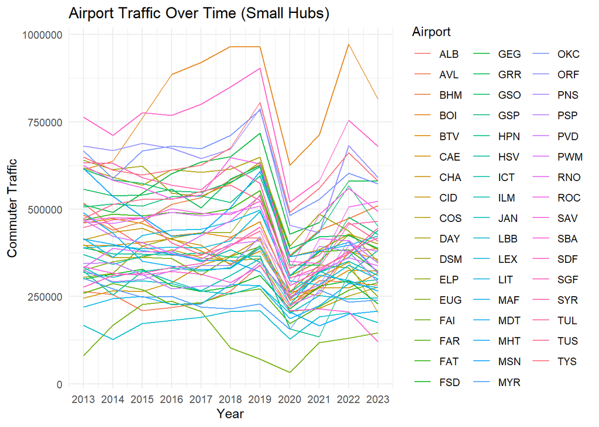

```r
ggplot(small_change, aes(x=SYSYEAR, y=COMMUTER, color=LOC_ID)) +
  geom_line() +
  theme_minimal() +
  labs(title="Airport Traffic Over Time (Small Hubs)",
       x="Year",
       y="Commuter Traffic",
       color="Airport") +
  scale_x_continuous(breaks=2013:2023)
```

The charts above highlight that Chicago and Boise are both the largest hubs in their respective size categories. However, in order to identify winners and losers, we are more interested in the change in commuter enplanements for hub airports from 2013 to 2023.

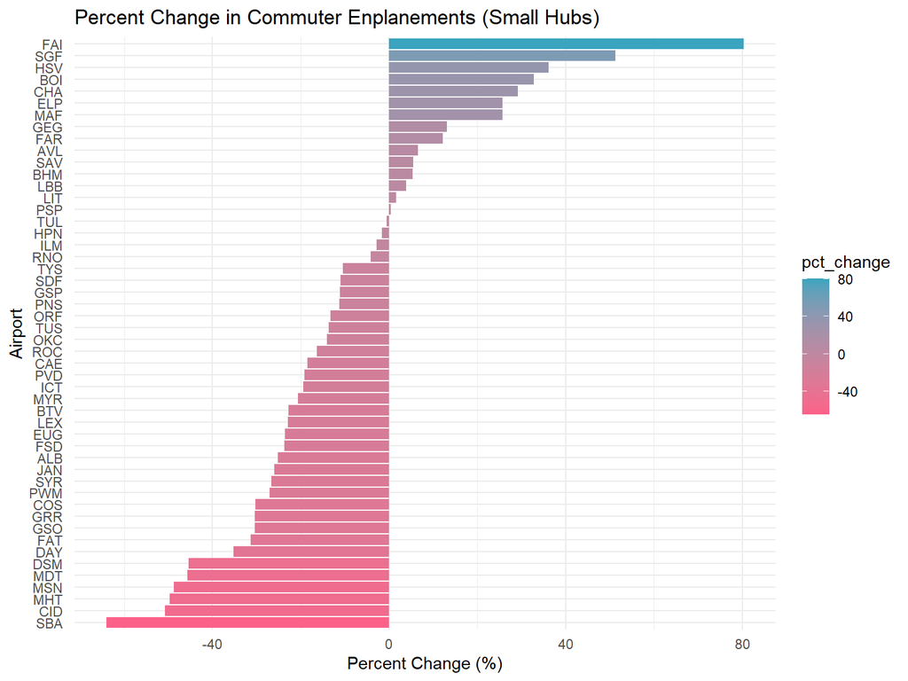

```r
#planning to chart hubs with the largest percentage change from 2013 to 2023 to determine winners & losers
large_change <- large_change %>%
  group_by(LOC_ID) %>%
  summarise(
    start_value = first(COMMUTER),
    end_value = last(COMMUTER),
    tot_change = end_value - start_value,
    pct_change = ((end_value - start_value) / start_value) * 100
  )

small_change <- small_change %>%
  group_by(LOC_ID) %>%
  summarise(
    start_value = first(COMMUTER),
    end_value = last(COMMUTER),
    tot_change = end_value - start_value,
    pct_change = ((end_value - start_value) / start_value) * 100
  )

# Horizontal Bar Chart - Percentage Change - Small Hubs
ggplot(small_change, aes(x = reorder(LOC_ID, pct_change), y = pct_change, fill = pct_change)) +
  geom_col() +
  coord_flip() +
  labs(title = "Percent Change in Commuter Enplanements (Small Hubs)",
       x = "Airport",
       y = "Percent Change (%)") +
  scale_fill_gradient(low = "#FC6189", high = "#3BA4BF") +
  theme_minimal()
```

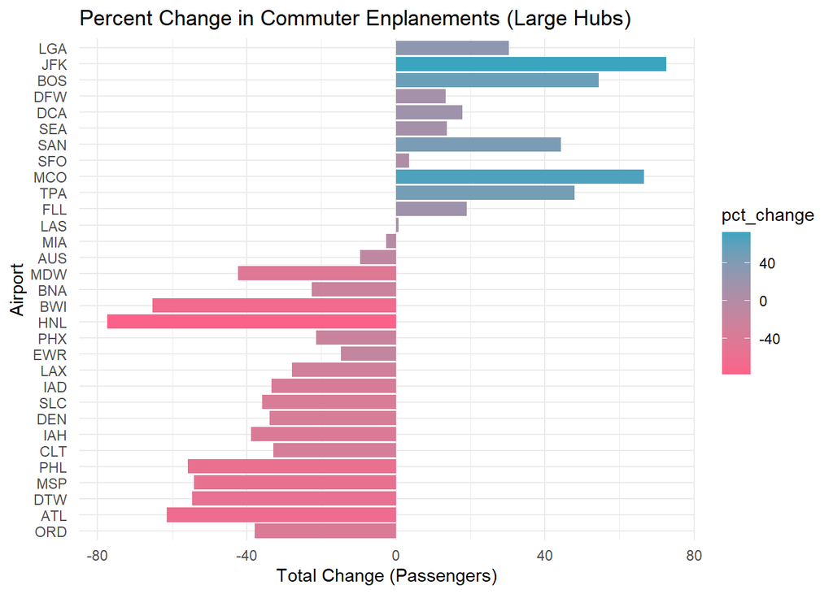

```r
# Horizontal Bar Chart - Percent Change - Large Hubs
ggplot(large_change, aes(x = reorder(LOC_ID, tot_change), y = pct_change, fill = pct_change)) +
  geom_col() +
  coord_flip() +
  labs(title = "Percent Change in Commuter Enplanements (Large Hubs)",
       x = "Airport",
       y = "Total Change (Passengers)") +
  scale_fill_gradient(low = "#FC6189", high = "#3BA4BF") +
  theme_minimal()
```

## Part Two: Airport Delay Patterns (2013-2023)

This analysis examines the operational efficiency of previously identified winner and loser airports by comparing their delay metrics between January 2013 and January 2023. Using data from the Office of Airline Information, Bureau of Transportation Statistics (BTS), we analyze both arrival and departure delays for each airport in their roles as origin and destination points. Delay metrics serve as our key indicators for measuring operational efficiency, as they reflect an airport’s ability to manage traffic flow and maintain service quality regardless of their hub status. By examining these metrics across different operational roles, we can better understand how changes in hub status affect an airport’s ability to handle traffic efficiently.

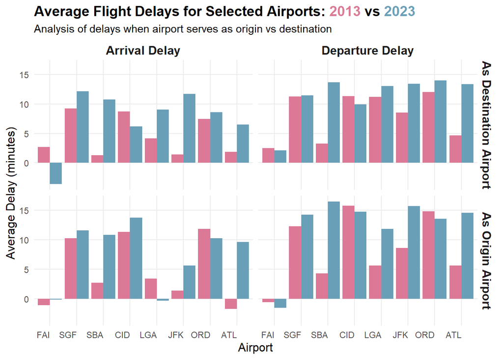

```r
# Combine datasets
combined_data <- bind_rows(
  performance_2013 %>% mutate(dataset = "2013"),
  performance_2023 %>% mutate(dataset = "2023")
)


airport_delays <- combined_data %>%
  # Create separate rows for origin and destination analysis
  pivot_longer(
    cols = c(Origin, Dest),
    names_to = "airport_role",
    values_to = "airport"
  ) %>%
  filter(airport %in% selected_airports) %>%
  group_by(dataset, airport, airport_role) %>%
  summarize(
    avg_dep_delay = mean(DepDelay, na.rm = TRUE),
    avg_arr_delay = mean(ArrDelay, na.rm = TRUE),
    n_flights = n()
  ) %>%
  ungroup()

# Create long format for plotting
delays_long <- airport_delays %>%
  pivot_longer(
    cols = c(avg_dep_delay, avg_arr_delay),
    names_to = "delay_type",
    values_to = "delay_minutes"
  )

# Visualization
ggplot(delays_long, aes(x = factor(airport, levels = selected_airports),
                       y = delay_minutes,
                       fill = dataset)) +
  geom_bar(stat = "identity", position = position_dodge(width = 0.9)) +
  facet_grid(airport_role ~ delay_type,
             labeller = labeller(
               delay_type = c(
                 "avg_dep_delay" = "Departure Delay",
                 "avg_arr_delay" = "Arrival Delay"),
               airport_role = c(
                 "Origin" = "As Origin Airport",
                 "Dest" = "As Destination Airport"))) +
  theme_minimal() +
  labs(
    title = "Average Flight Delays for Selected Airports: **<span style='color:#db7996;'>2013</span>** vs **<span style='color:#6a9fb8;'>2023</span>**",
    subtitle = "Analysis of delays when airport serves as origin vs destination",
    x = "Airport",
    y = "Average Delay (minutes)",
    fill = "Year"
  ) +
  scale_fill_manual(values = c("2013" = "#db7996", "2023" = "#6a9fb8")) +
  theme(
    axis.text.x = element_text(angle = 0, hjust = 1),
    axis.title = element_text(size = 12),
    plot.title = element_markdown(size = 14, face = "bold"),
    legend.position = "none",
    panel.grid.minor = element_blank(),
    strip.text = element_text(size = 12, face = "bold")
  )
```

```r
# Create summary statistics
summary_stats <- airport_delays %>%
  group_by(dataset, airport) %>%
  summarize(
    avg_dep_delay_as_origin = round(mean(avg_dep_delay[airport_role == "Origin"], na.rm = TRUE), 1),
    avg_arr_delay_as_origin = round(mean(avg_arr_delay[airport_role == "Origin"], na.rm = TRUE), 1),
    avg_dep_delay_as_dest = round(mean(avg_dep_delay[airport_role == "Dest"], na.rm = TRUE), 1),
    avg_arr_delay_as_dest = round(mean(avg_arr_delay[airport_role == "Dest"], na.rm = TRUE), 1),
    total_flights = sum(n_flights)
  ) %>%
  arrange(airport, dataset)


# Calculate year-over-year changes
delay_changes <- summary_stats %>%
  select(-total_flights) %>%
  pivot_wider(
    names_from = dataset,
    values_from = c(avg_dep_delay_as_origin, avg_arr_delay_as_origin,
                   avg_dep_delay_as_dest, avg_arr_delay_as_dest)
  ) %>%
  mutate(
    dep_delay_change_origin = avg_dep_delay_as_origin_2023 - avg_dep_delay_as_origin_2013,
    arr_delay_change_origin = avg_arr_delay_as_origin_2023 - avg_arr_delay_as_origin_2013,
    dep_delay_change_dest = avg_dep_delay_as_dest_2023 - avg_dep_delay_as_dest_2013,
    arr_delay_change_dest = avg_arr_delay_as_dest_2023 - avg_arr_delay_as_dest_2013
  )
```

```r
delay_table <- delay_changes %>%
  select(airport,
         dep_delay_change_origin,
         arr_delay_change_origin,
         dep_delay_change_dest,
         arr_delay_change_dest) %>%
  mutate(across(where(is.numeric), round, 1)) %>%
  rename(
    "Airport" = airport,
    "Departure Delay\n(as Origin)" = dep_delay_change_origin,
    "Arrival Delay\n(as Origin)" = arr_delay_change_origin,
    "Departure Delay\n(as Destination)" = dep_delay_change_dest,
    "Arrival Delay\n(as Destination)" = arr_delay_change_dest
  )

# Create a formatted table
kable(delay_table, format = "html",
      caption = "Changes in Flight Delays (2023 vs 2013) in Minutes") %>%
  kable_styling(bootstrap_options = c("striped", "hover", "condensed"),
                full_width = FALSE) %>%
  row_spec(0, bold = TRUE, background = "#f0f0f0") %>%
  column_spec(1, bold = TRUE) %>%
  add_header_above(c(" " = 1, "As Origin" = 2, "As Destination" = 2)) %>%
  footnote(
    general = "Positive values indicate increased delays in 2023 compared to 2013",
    general_title = "Note: "
  )
```

Changes in Flight Delays (2023 vs 2013) in Minutes

| Airport | As Origin Departure Delay (as Origin) | As Origin Arrival Delay (as Origin) | As Destination Departure Delay (as Destination) | As Destination Arrival Delay (as Destination) |
| --- | --- | --- | --- | --- |
| ATL | 8.9 | 11.3 | 8.7 | 4.6 |
| CID | -1.1 | 2.4 | -1.4 | -2.5 |
| FAI | -1.0 | 1.0 | -0.4 | -6.3 |
| JFK | 7.1 | 4.2 | 4.9 | 10.3 |
| LGA | 6.2 | -3.8 | 1.8 | 4.9 |
| ORD | -1.2 | -1.6 | 2.0 | 1.2 |
| SBA | 12.2 | 8.1 | 10.3 | 9.4 |
| SGF | 1.9 | 1.3 | 0.2 | 3.0 |

Note:  
Positive values indicate increased delays in 2023 compared to 2013